# Final project SMDS-2-2020

Zavadskaya Katsiaryna 1847985

## Flight Delays

The dataset contains information about flight delays for 14 airlines for each of the days of 2015. For the computations simplicity I grouped it in way that it is showing total number of flights performed and number of flights with a delay for all the airline companies during 1st of January 2015.

The original data can be accessed at: https://www.kaggle.com/usdot/flight-delays/data?select=flights.csv

### 1 - Data

The data is shown in the table below:

```r
flights <- read.csv("data/flights_summary_delays_2015_01_01_01.csv")
flights <- as.data.frame(flights)
flights
```

```
##    AIRLINE DELAYED.FLIGHTS TOTAL
## 1       AA             598  1380
## 2       AS             108   439
## 3       B6             249   757
## 4       DL             393  1559
## 5       EV             369  1266
## 6       F9             151   264
## 7       HA              83   209
## 8       MQ             359   703
## 9       NK             138   277
## 10      OO             550  1432
## 11      UA             771  1270
## 12      US             340  1029
## 13      VX              39   152
## 14      WN             491  1180
```

#### 1.1 - Data overview

As we can see from the data table, the airline name is encoded with two letters. The basic summaries about our numerical features can be seen below:

```r
summary(flights$TOTAL)
```

```
##    Min. 1st Qu.  Median    Mean 3rd Qu.    Max.
##   152.0   317.5   893.0   851.2  1269.0  1559.0
```

```r
summary(flights$DELAYED.FLIGHTS)
```

```
##    Min. 1st Qu.  Median    Mean 3rd Qu.    Max.
##    39.0   141.2   349.5   331.4   466.5   771.0
```

More in detail, the data available corresponds to 14 different airlines, having a minimum number of flights per day equal to 152 and a maximum of 1559. The delay rates are in the interval of minimum 39 and maximum 771 delayed flights per day.

Following we can see the graphic visualization of the data:

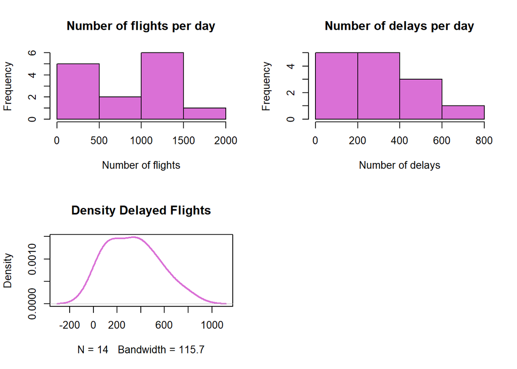

```r
# Histograms
par(mfrow=c(2,2))
hist(main='Number of flights per day', flights$TOTAL, xlab='Number of flights', ylab='Frequency', col='orchid')
hist(main='Number of delays per day', flights$DELAYED.FLIGHTS, xlab='Number of delays', ylab='Frequency', col='orchid')
d <- density(flights$DELAYED.FLIGHTS) # the density of the data
plot(d, main = "Density Delayed Flights", col = "orchid", lwd = 2)
```

### 2 - Model description

Lets denote total number of flights performed by each airline $i$ as $n_i$. The number of delayed flights will be ${r_i}$ which is a binary response variable with ‘true’ delay probability ${p_i}$. In order to model the outcome I am going to use Binomial distribution.

$r_i \sim Binomial(p_i,n_i)$

The aim of my analysis is to estimate parameters of the Binomial distribution for each of the airlines.

Additionally, it is assumed that the true delay probabilities are independent for each airline. A standard non-informative prior distribution for the $p_i$ is following:

$p_i \sim Beta(1.0,1.0)$

The Beta distribution is a continuous distribution that only takes values between 0 to 1. And we need a prior for each of the $p_i$.

In order to make inference in an automatic way, I am writing a model for JAGS.

#### 2.1 - Data preparation for JAGS

Since JAGS is not able to deal with dataframes, I need to transform data into lists.

```r
n <- flights$TOTAL
r <- flights$DELAYED.FLIGHTS
N <- nrow(flights)
flights.jags <- list("r", "n", "N")
```

#### 2.2 - JAGS Model

The following code was executed in order to find probabilities of delay for each airline.

```r
# Model
model <- function() {
  for(i in 1:N){
    p[i] ~ dbeta(1.0, 1.0) # Prior
    r[i] ~ dbinom(p[i], n[i]) # Model
  }
}

# Starting values
mod.inits = function(){
  list("p" = c(0.1, 0.1, 0.1, 0.1,0.1, 0.1, 0.1, 0.1, 0.1, 0.1, 0.1, 0.1, 0.1, 0.1))
  }

# Run JAGS
set.seed(123)
mod.fit <- jags(data = flights.jags,
                model.file = model, inits = mod.inits,
                parameters.to.save = 'p',
                n.chains = 3, n.iter = 10000, n.burnin = 1000, n.thin=5)
```

```
## module glm loaded
```

#### 2.3 - Output and Diagnostic

```r
mod.fit
```

```
## Inference for Bugs model at "C:/Users/zavad/AppData/Local/Temp/RtmpAXcAYs/model191027b83a3d.txt", fit using jags,
##  3 chains, each with 10000 iterations (first 1000 discarded), n.thin = 5
##  n.sims = 5400 iterations saved
##          mu.vect sd.vect    2.5%     25%     50%     75%   97.5%  Rhat n.eff
## p[1]       0.434   0.013   0.408   0.424   0.433   0.443   0.460 1.001  5400
## p[2]       0.247   0.020   0.208   0.233   0.247   0.261   0.289 1.001  5400
## p[3]       0.330   0.017   0.298   0.318   0.329   0.341   0.365 1.001  5400
## p[4]       0.253   0.011   0.231   0.245   0.252   0.260   0.274 1.001  5400
## p[5]       0.292   0.013   0.267   0.283   0.291   0.300   0.318 1.001  5400
## p[6]       0.571   0.030   0.510   0.551   0.572   0.592   0.630 1.001  5400
## p[7]       0.398   0.034   0.333   0.375   0.398   0.421   0.466 1.001  5400
## p[8]       0.511   0.019   0.473   0.498   0.511   0.524   0.547 1.001  5400
## p[9]       0.499   0.030   0.440   0.478   0.498   0.519   0.559 1.001  5400
## p[10]      0.384   0.013   0.358   0.376   0.384   0.392   0.409 1.001  5400
## p[11]      0.607   0.014   0.580   0.598   0.607   0.616   0.633 1.001  5400
## p[12]      0.330   0.015   0.301   0.320   0.330   0.340   0.360 1.001  3100
## p[13]      0.259   0.035   0.192   0.236   0.258   0.283   0.329 1.002  2500
## p[14]      0.416   0.014   0.388   0.406   0.416   0.426   0.444 1.001  5400
## deviance 109.834   5.253 101.370 105.997 109.310 112.888 121.649 1.001  5400
##
## For each parameter, n.eff is a crude measure of effective sample size,
## and Rhat is the potential scale reduction factor (at convergence, Rhat=1).
##
## DIC info (using the rule, pD = var(deviance)/2)
## pD = 13.8 and DIC = 123.6
## DIC is an estimate of expected predictive error (lower deviance is better).
```

```r
mod.fit$BUGSoutput$summary
```

```
##                 mean         sd        2.5%         25%         50%         75%
## deviance 109.8338763 5.25336892 101.3696341 105.9966731 109.3095628 112.8878433
## p[1]       0.4335867 0.01335332   0.4078102   0.4243691   0.4334973   0.4427816
## p[2]       0.2474974 0.02047418   0.2081075   0.2332999   0.2470569   0.2613559
## p[3]       0.3296202 0.01704017   0.2980731   0.3179589   0.3291902   0.3409677
## p[4]       0.2525435 0.01108803   0.2306998   0.2451409   0.2524485   0.2597553
## p[5]       0.2917440 0.01277840   0.2671345   0.2831159   0.2913724   0.3004976
## p[6]       0.5714301 0.03011977   0.5102846   0.5512479   0.5719047   0.5919380
## p[7]       0.3982756 0.03391187   0.3329866   0.3750708   0.3979066   0.4211728
## p[8]       0.5106153 0.01866918   0.4733838   0.4982308   0.5107250   0.5236131
## p[9]       0.4985123 0.03022186   0.4398095   0.4780103   0.4981580   0.5188950
## p[10]      0.3839745 0.01272029   0.3584760   0.3755504   0.3838633   0.3924112
## p[11]      0.6069232 0.01369327   0.5798501   0.5978142   0.6070263   0.6163607
## p[12]      0.3302953 0.01485607   0.3010981   0.3200626   0.3304798   0.3402740
## p[13]      0.2594080 0.03497616   0.1920310   0.2356330   0.2583612   0.2826380
## p[14]      0.4159283 0.01448804   0.3878991   0.4062966   0.4158641   0.4257915
##                97.5%     Rhat n.eff
## deviance 121.6490342 1.000814  5400
## p[1]       0.4596816 1.000734  5400
## p[2]       0.2885156 1.000864  5400
## p[3]       0.3645335 1.000859  5400
## p[4]       0.2742554 1.000763  5400
## p[5]       0.3176901 1.000833  5400
## p[6]       0.6299553 1.001033  5400
## p[7]       0.4656138 1.000887  5400
## p[8]       0.5466687 1.001084  5400
## p[9]       0.5586279 1.000747  5400
## p[10]      0.4093025 1.000794  5400
## p[11]      0.6331683 1.000980  5400
## p[12]      0.3600285 1.001371  3100
## p[13]      0.3292403 1.001508  2500
## p[14]      0.4440824 1.001012  5400
```

Next I want to understand if I can trust the MCMC results. To do that I want to see if there any evidence that the chains are stationary, i.e. if the simulated parameters values are moving in a consistent direction.

To get a visual idea about what is happening in a chain, I extract it from the model output.

```r
chainArray <- mod.fit$BUGSoutput$sims.array
```

Next I look at the traceplots in order to inspect sampling behavior and assess mixing across chains and convergence. Lets first look at all the traceplots and then have a closer view of one of them:

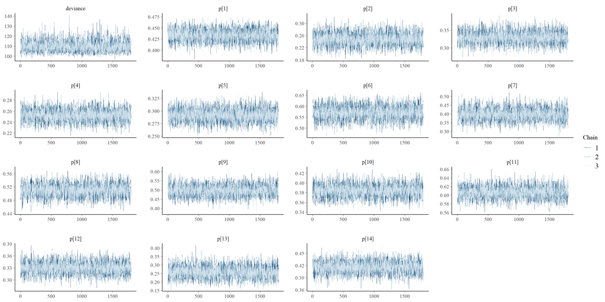

```r
mcmc_trace(chainArray)
```

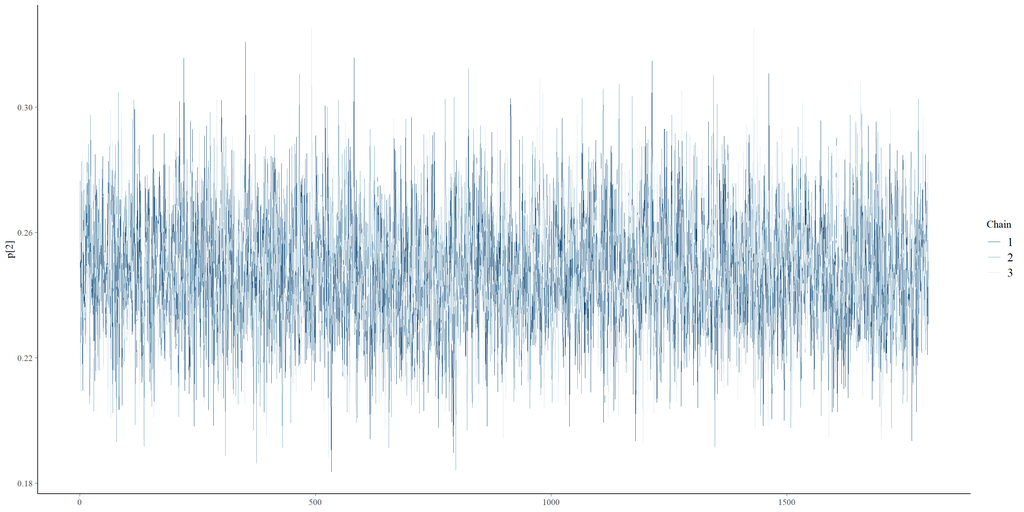

```r
mcmc_trace(chainArray, pars="p[2]")
```

While examining the following traceplots I see that chains are visualized just on top of each other, which means that all 3 chains converged towards the same value. I conclude that there can not be seen any evidence that the chain has not achieved stationarity.

The next diagnostic step is to look at the plots of estimated density of the parameters and of the deviance, where density plots are just smoothed histograms of the samples.

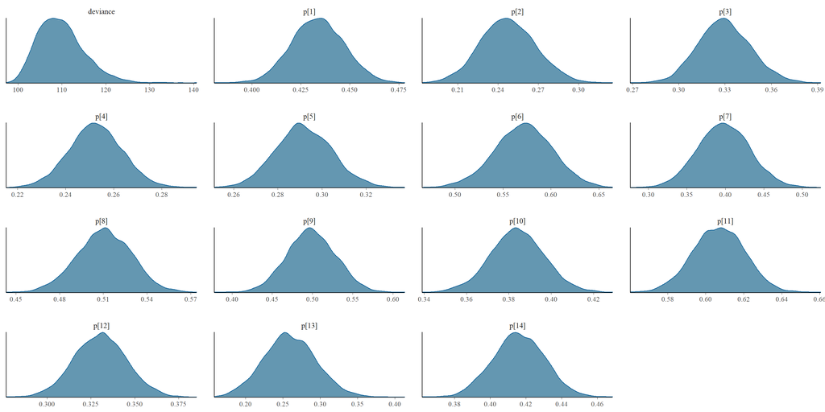

```r
mcmc_dens(chainArray)
```

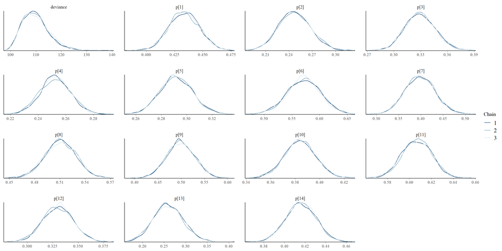

```r
mcmc_dens_overlay(chainArray)
```

The third way is to check autocorrelation plots. These plots are specific for each of the chains. I expect to see low autocorrelation, since it indicates convergence. And as it can be seen on the plot, the autocorrelation function drops to 0 pretty fast, after only a couple of lags.

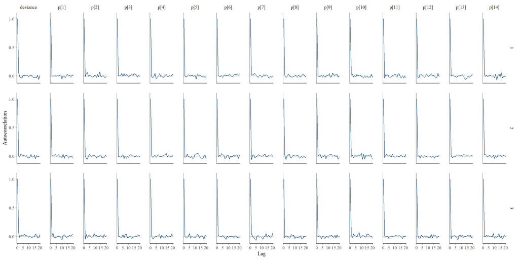

```r
bayesplot::mcmc_acf(chainArray)
```

### 3 - Inferential findings

Lets first join the deviance and p[i] for all 3 chains:

```r
chainMat <- mod.fit$BUGSoutput$sims.matrix
```

Now the point estimates can be seen:

```r
p.hat.jags <- colMeans(chainMat)
p.hat.jags
```

```
##    deviance        p[1]        p[2]        p[3]        p[4]        p[5]
## 109.8338763   0.4335867   0.2474974   0.3296202   0.2525435   0.2917440
##        p[6]        p[7]        p[8]        p[9]       p[10]       p[11]
##   0.5714301   0.3982756   0.5106153   0.4985123   0.3839745   0.6069232
##       p[12]       p[13]       p[14]
##   0.3302953   0.2594080   0.4159283
```

When it comes to interval estimation, first lets see equal tail intervals:

```r
cred <- 0.95
p.ET.jags <- apply(chainMat, 2, quantile, prob=c((1-cred)/2, 1-(1-cred)/2))
p.ET.jags
```

```
##       deviance      p[1]      p[2]      p[3]      p[4]      p[5]      p[6]
## 2.5%  101.3696 0.4078102 0.2081075 0.2980731 0.2306998 0.2671345 0.5102846
## 97.5% 121.6490 0.4596816 0.2885156 0.3645335 0.2742554 0.3176901 0.6299553
##            p[7]      p[8]      p[9]     p[10]     p[11]     p[12]     p[13]
## 2.5%  0.3329866 0.4733838 0.4398095 0.3584760 0.5798501 0.3010981 0.1920310
## 97.5% 0.4656138 0.5466687 0.5586279 0.4093025 0.6331683 0.3600285 0.3292403
##           p[14]
## 2.5%  0.3878991
## 97.5% 0.4440824
```

And also HPD intervals:

```r
p.HPD.jags <- coda::HPDinterval(as.mcmc(chainMat))
p.HPD.jags
```

```
##                lower       upper
## deviance 100.6330497 120.2236135
## p[1]       0.4079480   0.4596908
## p[2]       0.2078102   0.2880092
## p[3]       0.2971488   0.3633637
## p[4]       0.2307793   0.2743472
## p[5]       0.2657401   0.3161712
## p[6]       0.5091683   0.6283361
## p[7]       0.3316173   0.4632870
## p[8]       0.4732031   0.5464167
## p[9]       0.4381948   0.5557763
## p[10]      0.3586156   0.4094553
## p[11]      0.5795786   0.6327434
## p[12]      0.2999506   0.3586745
## p[13]      0.1907935   0.3271863
## p[14]      0.3878907   0.4440276
## attr(,"Probability")
## [1] 0.95
```

### 4 Alternative model

In the first model it was assumed that the true delay probabilities are independent for each airline. However, a more realistic model for flights delay is that the delay rates across airline companies are similar in some way.

$r_i \sim Binomial(p_i,n_i)$

$\log(p_i/(1-p_i) \sim Normal(\mu,\tau^{2})$

In this model we assume that the logit of each airline’s rate is related to each other. Standard priors are given by:

$\mu \sim Normal(0, 1*10^{-6})$

$1/\tau^{2} \sim Gamma(0.001, 0.001)$

Standard non-informative priors are specified for the population mean (logit) probability of delay - $\mu$ , and precision - $\tau$.

#### 4.1 - Data preparation for JAGS

Since JAGS is not able to deal with dataframes, I need to transform data into lists.

```r
n <- flights$TOTAL
r <- flights$DELAYED.FLIGHTS
N <- nrow(flights)
flights.jags2 <- list("r", "n", "N")
```

#### 4.2 - JAGS Model

The following code was executed in order to find probabilities of delay for each airline.

```r
# Model
model2 <- function() {
  for(i in 1:N){
    r[i] ~ dbinom(p[i], n[i]) #Model
    b[i] ~ dnorm(mu,tau)
    logit(p[i]) <- b[i]
  }
  mu ~ dnorm(0.0, 1.0E-6) #Priors
  tau ~ dgamma(0.001, 0.001)

  sigma <- 1 / sqrt(tau)
  pop.mean <- exp(mu) / (1 + exp(mu))
}

# Starting values
mod.inits2 = function(){
  list(b = c(0.1, 0.1, 0.1, 0.1, 0.1, 0.1, 0.1, 0.1, 0.1, 0.1, 0.1, 0.1, 0.1, 0.1),
       tau = 1,
       mu = 0)
}

# Run JAGS
set.seed(123)
mod.fit2 <- jags(data = flights.jags2,
                model.file = model2, inits = mod.inits2,
                parameters.to.save = c("p","sigma","mu","pop.mean"),
                n.chains = 3, n.iter = 10000, n.burnin = 1000, n.thin=5)
```

#### 4.3 - Output and Diagnostic

```r
mod.fit2
```

```
## Inference for Bugs model at "C:/Users/zavad/AppData/Local/Temp/RtmpAXcAYs/model191089f7d69.txt", fit using jags,
##  3 chains, each with 10000 iterations (first 1000 discarded), n.thin = 5
##  n.sims = 5400 iterations saved
##          mu.vect sd.vect    2.5%     25%     50%     75%   97.5%  Rhat n.eff
## mu        -0.453   0.148  -0.754  -0.548  -0.454  -0.358  -0.163 1.002  2400
## p[1]       0.433   0.013   0.407   0.424   0.433   0.442   0.459 1.001  5000
## p[2]       0.252   0.020   0.216   0.238   0.252   0.266   0.293 1.001  4400
## p[3]       0.330   0.017   0.298   0.318   0.330   0.342   0.364 1.001  5400
## p[4]       0.254   0.011   0.233   0.246   0.254   0.261   0.275 1.001  5400
## p[5]       0.293   0.013   0.269   0.285   0.293   0.301   0.318 1.001  5400
## p[6]       0.561   0.030   0.502   0.541   0.560   0.581   0.619 1.001  2900
## p[7]       0.396   0.032   0.334   0.374   0.396   0.418   0.460 1.001  5400
## p[8]       0.508   0.018   0.471   0.496   0.509   0.520   0.544 1.001  5400
## p[9]       0.492   0.029   0.433   0.472   0.491   0.512   0.548 1.001  3500
## p[10]      0.384   0.013   0.358   0.375   0.384   0.393   0.409 1.001  4800
## p[11]      0.604   0.014   0.578   0.595   0.605   0.614   0.631 1.001  2800
## p[12]      0.331   0.015   0.302   0.321   0.331   0.341   0.361 1.001  5400
## p[13]      0.271   0.034   0.206   0.247   0.270   0.293   0.340 1.001  2700
## p[14]      0.416   0.014   0.389   0.406   0.416   0.425   0.444 1.001  5400
## pop.mean   0.389   0.035   0.320   0.366   0.388   0.411   0.459 1.002  2100
## sigma      0.531   0.117   0.358   0.448   0.513   0.592   0.807 1.001  5400
## deviance 109.841   5.310 101.526 105.971 109.152 112.987 121.852 1.001  3900
##
## For each parameter, n.eff is a crude measure of effective sample size,
## and Rhat is the potential scale reduction factor (at convergence, Rhat=1).
##
## DIC info (using the rule, pD = var(deviance)/2)
## pD = 14.1 and DIC = 123.9
## DIC is an estimate of expected predictive error (lower deviance is better).
```

```r
mod.fit2$BUGSoutput$summary
```

```
##                 mean         sd        2.5%         25%         50%         75%
## deviance 109.8412511 5.31029040 101.5261685 105.9714164 109.1524822 112.9865160
## mu        -0.4530286 0.14777265  -0.7540523  -0.5476685  -0.4540381  -0.3583801
## p[1]       0.4331404 0.01328908   0.4070035   0.4239257   0.4330335   0.4423191
## p[2]       0.2524845 0.02028315   0.2155742   0.2383863   0.2519560   0.2660736
## p[3]       0.3301977 0.01698429   0.2980404   0.3183467   0.3299032   0.3419373
## p[4]       0.2537127 0.01081429   0.2325723   0.2463771   0.2535599   0.2610302
## p[5]       0.2930148 0.01253556   0.2688110   0.2845490   0.2927682   0.3011748
## p[6]       0.5607297 0.02963685   0.5020543   0.5414603   0.5601238   0.5807725
## p[7]       0.3963296 0.03231126   0.3338276   0.3742128   0.3958015   0.4181360
## p[8]       0.5080360 0.01844823   0.4711557   0.4959497   0.5085354   0.5203808
## p[9]       0.4917137 0.02937084   0.4332825   0.4722972   0.4913437   0.5121185
## p[10]      0.3841844 0.01292893   0.3584525   0.3752468   0.3843401   0.3929569
## p[11]      0.6044296 0.01360852   0.5780580   0.5952756   0.6046006   0.6136014
## p[12]      0.3312610 0.01481624   0.3021810   0.3212562   0.3312588   0.3409657
## p[13]      0.2706585 0.03416590   0.2059279   0.2473697   0.2698858   0.2934376
## p[14]      0.4157308 0.01409632   0.3886772   0.4060071   0.4156628   0.4254419
## pop.mean   0.3892113 0.03493214   0.3199390   0.3664055   0.3884011   0.4113518
## sigma      0.5311013 0.11688751   0.3578724   0.4484438   0.5134127   0.5920832
##                97.5%     Rhat n.eff
## deviance 121.8520086 1.001238  3900
## mu        -0.1629624 1.001568  2400
## p[1]       0.4590103 1.001119  5000
## p[2]       0.2929870 1.001179  4400
## p[3]       0.3636252 1.001070  5400
## p[4]       0.2749915 1.000796  5400
## p[5]       0.3180760 1.000772  5400
## p[6]       0.6185526 1.001412  2900
## p[7]       0.4604169 1.000767  5400
## p[8]       0.5438350 1.000840  5400
## p[9]       0.5481266 1.001291  3500
## p[10]      0.4092241 1.001139  4800
## p[11]      0.6308689 1.001435  2800
## p[12]      0.3605578 1.000844  5400
## p[13]      0.3397476 1.001457  2700
## p[14]      0.4435742 1.000768  5400
## pop.mean   0.4593493 1.001668  2100
## sigma      0.8066320 1.000795  5400
```

Next I want to understand if I can trust the MCMC results. To do that I repeat the process exactly as for model 1.

```r
chainArray2 <- mod.fit2$BUGSoutput$sims.array
```

Traceplots:

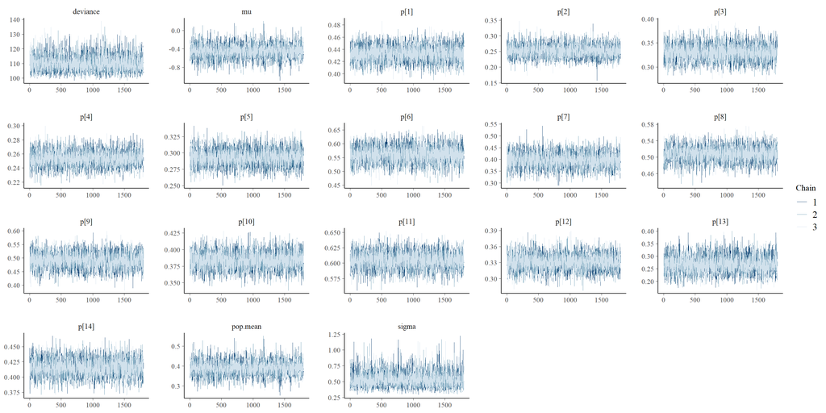

```r
mcmc_trace(chainArray2)
```

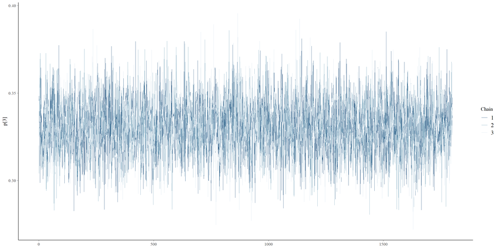

```r
mcmc_trace(chainArray2, pars="p[3]")
```

While examining the following traceplots I see that chains are visualized just on top of each other, which means that all 3 chains converged towards the same value. I conclude that there can not be seen any evidence that the chain has not achieved stationarity.

Density:

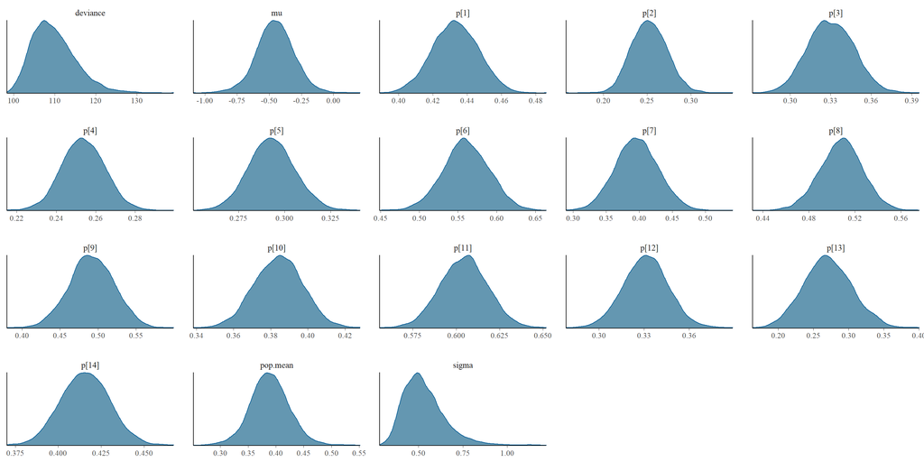

```r
mcmc_dens(chainArray2)
```

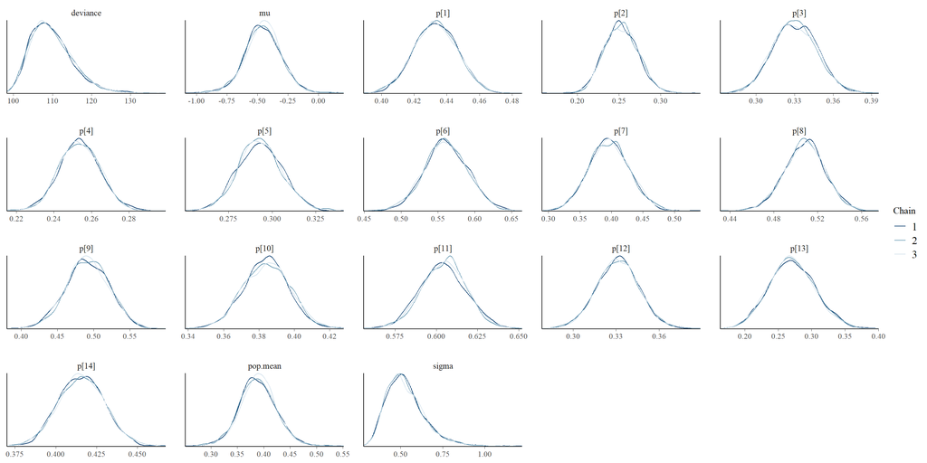

```r
mcmc_dens_overlay(chainArray2)
```

Autocorrelation plots:

[figure not shown]

```r
bayesplot::mcmc_acf(chainArray)
```

[output not shown]

### 5 - Inferential findings of the model 2

```r
chainMat2 <- mod.fit2$BUGSoutput$sims.matrix
```

Now the point estimates can be seen:

```r
p.hat.jags2 <- colMeans(chainMat2)
p.hat.jags2
```

```
##    deviance          mu        p[1]        p[2]        p[3]        p[4]
## 109.8412511  -0.4530286   0.4331404   0.2524845   0.3301977   0.2537127
##        p[5]        p[6]        p[7]        p[8]        p[9]       p[10]
##   0.2930148   0.5607297   0.3963296   0.5080360   0.4917137   0.3841844
##       p[11]       p[12]       p[13]       p[14]    pop.mean       sigma
##   0.6044296   0.3312610   0.2706585   0.4157308   0.3892113   0.5311013
```

Equal tail intervals:

```r
cred <- 0.95
p.ET.jags2 <- apply(chainMat2, 2, quantile, prob=c((1-cred)/2, 1-(1-cred)/2))
p.ET.jags2
```

```
##       deviance         mu      p[1]      p[2]      p[3]      p[4]     p[5]
## 2.5%  101.5262 -0.7540523 0.4070035 0.2155742 0.2980404 0.2325723 0.268811
## 97.5% 121.8520 -0.1629624 0.4590103 0.2929871 0.3636252 0.2749915 0.318076
##            p[6]      p[7]      p[8]      p[9]     p[10]     p[11]     p[12]
## 2.5%  0.5020543 0.3338276 0.4711557 0.4332825 0.3584525 0.5780580 0.3021810
## 97.5% 0.6185526 0.4604169 0.5438350 0.5481266 0.4092241 0.6308689 0.3605578
##           p[13]     p[14]  pop.mean     sigma
## 2.5%  0.2059279 0.3886772 0.3199390 0.3578724
## 97.5% 0.3397476 0.4435742 0.4593493 0.8066320
```

HPD intervals:

```r
p.HPD.jags2 <- coda::HPDinterval(as.mcmc(chainMat2))
p.HPD.jags2
```

```
##                lower       upper
## deviance 100.2560217 120.0753624
## mu        -0.7694048  -0.1802834
## p[1]       0.4075892   0.4595608
## p[2]       0.2155273   0.2929355
## p[3]       0.2987348   0.3640947
## p[4]       0.2333024   0.2755762
## p[5]       0.2691959   0.3182366
## p[6]       0.5048182   0.6206116
## p[7]       0.3368868   0.4630475
## p[8]       0.4686773   0.5413385
## p[9]       0.4318460   0.5462558
## p[10]      0.3594355   0.4097597
## p[11]      0.5780624   0.6308800
## p[12]      0.3021089   0.3604324
## p[13]      0.2046223   0.3382495
## p[14]      0.3887815   0.4436623
## pop.mean   0.3166079   0.4550508
## sigma      0.3454010   0.7761216
## attr(,"Probability")
## [1] 0.95
```

### 5 - Comparison of the models

In order to compare two different models I need to use term DIC - Deviance Information Criterion. DIC is a Bayesian method for model comparison and a measure for the prediction error of a model. The lower DIC value the better the model fits the data.

The deviance D, given a parameter value $\theta$ returns error using the log-likelihood function: $D(\theta) = -2 \text{log} * L(data|\theta)$

Once the posterior means are computed, I can measure their deviance as:

$D(\hat{\theta}) = -2 \text{log} * L(data|\hat{\theta})$ Taking all steps i in the different MCMCs, we can from this compute an average - posterior mean of the deviance as follows:

$\hat{D} = \frac{1}{M}\sum^{M}_{i=1}D (\theta_{i})$

Now it is possible to compute the effective number of parameters:

$p_{D} = \hat{D} - D(\hat{\theta})$

The DIC is then computed:

```r
paste("Model 1 DIC:",round(mod.fit$BUGSoutput$DIC,digits = 3),'         ',"Model 2 DIC",round(mod.fit2$BUGSoutput$DIC,digits = 3))
```

```
## [1] "Model 1 DIC: 123.637           Model 2 DIC 123.939"
```

Looking at the DIC values, it is obvious that the difference is not significant. And in fact the difference is equal to:

```r
paste("DIC Difference:", round(abs(mod.fit$BUGSoutput$DIC - mod.fit2$BUGSoutput$DIC),digits = 3))
```

```
## [1] "DIC Difference: 0.302"
```

The conclusion I can draw is that it is not possible to say exactly which model out of two is better.

### 6 - Comparison with frequentist inference

Instead of using MCMC approximation for estimation of each of the probabilities, it is also possible to estimate CI of their mean and standard deviation using Bootstarp.

Firstly, I compute probabilities by dividing column ‘DELAYED.FLIGHTS’ by column ‘TOTAL’:

```r
flights$PROB =  flights$DELAYED.FLIGHTS / flights$TOTAL
flights
```

```
##    AIRLINE DELAYED.FLIGHTS TOTAL      PROB
## 1       AA             598  1380 0.4333333
## 2       AS             108   439 0.2460137
## 3       B6             249   757 0.3289300
## 4       DL             393  1559 0.2520847
## 5       EV             369  1266 0.2914692
## 6       F9             151   264 0.5719697
## 7       HA              83   209 0.3971292
## 8       MQ             359   703 0.5106686
## 9       NK             138   277 0.4981949
## 10      OO             550  1432 0.3840782
## 11      UA             771  1270 0.6070866
## 12      US             340  1029 0.3304179
## 13      VX              39   152 0.2565789
## 14      WN             491  1180 0.4161017
```

At first number of sampling was picked. After that in the loop list of estimated probabilities that we calculated below was resampled with replacement. Mean and Standard deviation of each sample were saved. Using percentiles we can construct our Confidence Intervals.

```r
PROB_Matrix <- as.matrix(flights$PROB)
n = nrow(flights)
B <- 1000

our_out_put <- rep(NA,B) # empty vector
our_out_sd <- rep(NA,B)

for (b in 1:B){
  new_sample <- PROB_Matrix[sample(n,n,replace=TRUE),]
  our_out_put[b] <- mean(new_sample)
  our_out_sd[b] <- sqrt(var(new_sample))
}

paste("Mean Lower Bound:", quantile(our_out_put, c(0.025)),"Mean Upper Bound:",quantile(our_out_put, c(0.975)))
```

```
## [1] "Mean Lower Bound: 0.336190411360094 Mean Upper Bound: 0.455457749335132"
```

```r
paste("SD Lower Bound:", quantile(our_out_sd, c(0.025)),"SD Upper Bound:",quantile(our_out_sd, c(0.975)))
```

```
## [1] "SD Lower Bound: 0.0795848992606467 SD Upper Bound: 0.143555418660783"
```